# Visualización y exploración de datos

Última actualización:

13 de marzo de 2026

# Preparación

Necesitamos tener instalados los paquetes `ggplot2` y `qvalue` en R. En la carpeta de trabajo encontraréis también los datos necesarios.

# Objetivos

1. Practicar la representación gráfica de datos con `ggplot2`.
2. Aprender lo que es una gráfica volcán y una gráfica de Manhattan.
3. Demostrar que la exploración gráfica puede ayudarnos a comprender los datos.

# Datos

En esta sesión, trabajaremos con los resultados de un análisis de asociación genómica entre un fenotipo cuantitativo y los genotipos de 195 peces en 11746 posiciones variables o SNPs de su genoma. El archivo `gwas.txt` ha sido obtenido con el programa [PLINK2](https://www.cog-genomics.org/plink/2.0/) (Purcell et al. 2007; Chang et al. 2015). Contiene 16 columnas, descritas a continuación y también [en este enlace](https://www.cog-genomics.org/plink/2.0/formats#glm_linear):

- **CHROM**, **POS**, **ID**: cromosoma, posición e identificador del SNP.
- **REF**: alelo de referencia.
- **ALT**: alelo alternativo.
- **PROVISIONAL_REF.**: indica si el alelo de referencia es provisional o no.
- **A1**: alelo cuya dosis se usa en la regresión como variable independiente.
- **OMITTED**: el otro alelo.
- **A1_FREQ**: frecuencia del alelo A1 en la población.
- **TEST**: test estadístico aplicado. *ADD*: el efecto aditivo del alelo A1 es nulo.
- **OBS_CT**: tamaño muestral (número de individuos) en la regresión.
- **BETA**: coeficiente de regresión estimado para el alelo A1.
- **SE**: error estándar del coeficiente de regresión.
- **T_STAT**: estadístico *T*.
- **P**: valor *p* del estadístico.
- **ERRCODE**: código de error, si lo hay, o bien “.” (sin error).

Cargamos los datos en una sesión de R para empezar a explorarlos, y activamos el paquete `ggplot2`, que usaremos después.

```r
library('ggplot2')
gwas <- read.table('gwas.txt')
```

**NotaDesafío**

La orden `read.table('gwas.txt')` no da error, pero es errónea. ¿Puedes arreglarla?

Los nombres de las columnas no los ha entendido como tal, hay que especificarlo. Además, hay filas que en P tienen NA, y podemos eliminarlas y reasignar la tabla

```r
gwas <- read.table('gwas.txt', header = TRUE, sep= '\t')
# Aquí le decimos que se quede solo con los datos que en la columna 'P' tienen un valor distinto a NA
gwas <- gwas[!is.na(gwas$P),]
```

# Comprobar las suposiciones

Sabemos que el estadístico *T* es la relación entre la diferencia del valor estimado de un parámetro ($\beta$) respecto su valor asumido (0) y el error estándar de la estimación. Comprobémoslo con `ggplot()`:

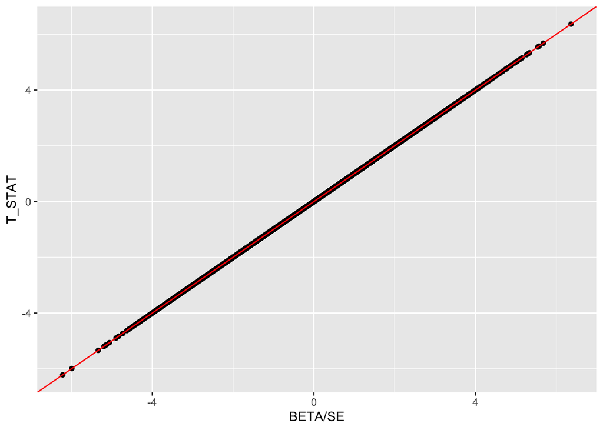

```r
ggplot(data = gwas,
       mapping = aes(x = BETA / SE, y = T_STAT)) +
   geom_point() +
   geom_abline(intercept = 0, slope = 1, color = 'red')
```

**NotaDesafío**

Comprueba gráficamente las suposiciones siguientes. Esfuérzate por imaginar qué forma esperas que adopte la gráfica en cada caso antes de representarla. Si en algún caso encuentras una relación diferente a la esperada, trata de explicarte por qué.

1. El valor *p* sólo depende del estadístico *T*.

   Cuanto más se acerca el valor de T a cero, mayor es el p-valor, por lo que los datos más fiables son los que tienen T más lejano a 0, tanto en valores positivos como negativos.

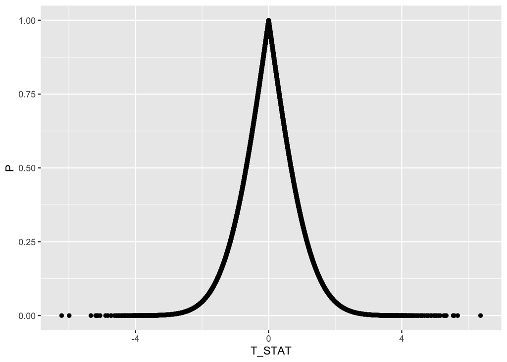

   ```r
   ggplot(data = gwas,
          mapping = aes(x = T_STAT, y = P)) +
      geom_point()
   ```

2. El alelo A1 es siempre el que tiene la frecuencia más baja, en estos datos.

   Asumiendo que hay dos alelos, si A1 tiene una frecuencia menor que 0,5 sabemos que siempre será el menos abundante. Al representar los datos en el histograma vemos cuál es su frecuencia máxima y que nunca llega a ser mayor de 0,5, por lo que realmente es el de menor frecuencia.

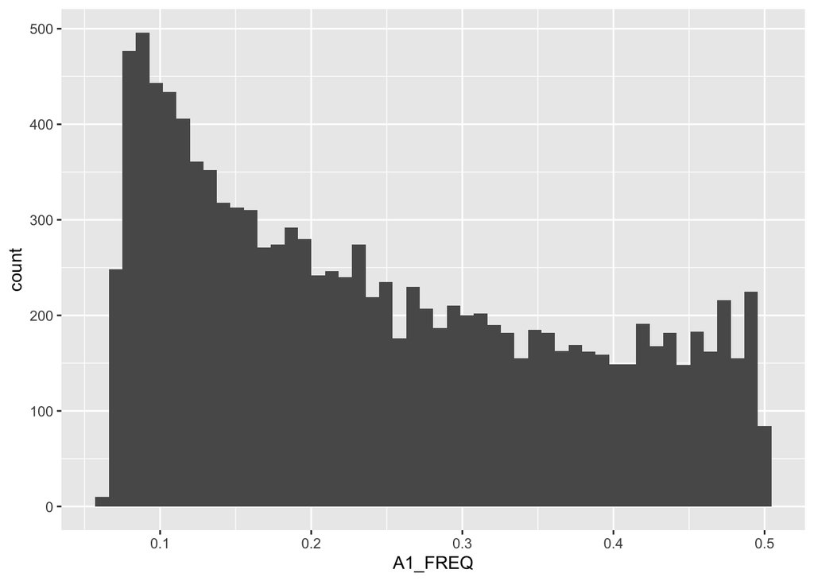

   ```r
   ggplot(data = gwas,
          mapping = aes(x = A1_FREQ)) +
      geom_histogram(bins = 50)
   ```

3. El error estándar es menor cuanto mayor es el tamaño muestral.

   Representamos el error estándar en función al tamaño muestral. A partir de los datos representados no se puede deducir ninguna relación lineal que indique que el error disminuya cuanto mayor sea el tamaño muestral.

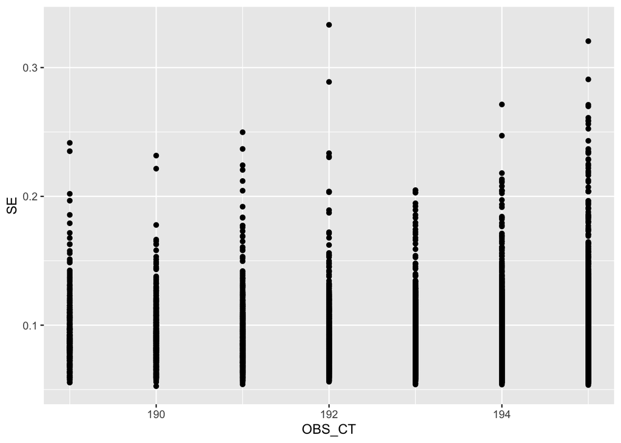

   ```r
   ggplot(data = gwas,
          mapping = aes(x = OBS_CT, y = SE)) +
      geom_point()
   ```

4. La distribución de valores *p* se hace uniforme hacia la derecha.

   Cuanto mayor es el p-valor, más se debe el resultado al azar, por lo que la frecuencia se iguala.

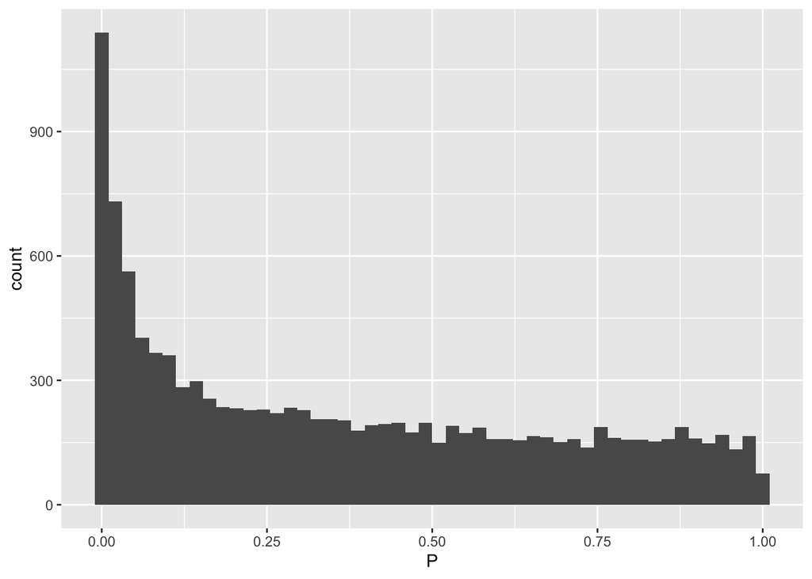

   ```r
   ggplot(data = gwas,
          mapping = aes(x = P)) +
      geom_histogram(bins = 50)
   ```

# Agrupación de datos

Podemos mapear una variable categórica a un estético como el color, el tipo de línea o la forma del punto, para representar datos de diferentes categorías separadamente. A continuación usamos el color para resumir la relación entre frecuencia alélica y error estándar del estadístico, según el número de individuos utilizados.

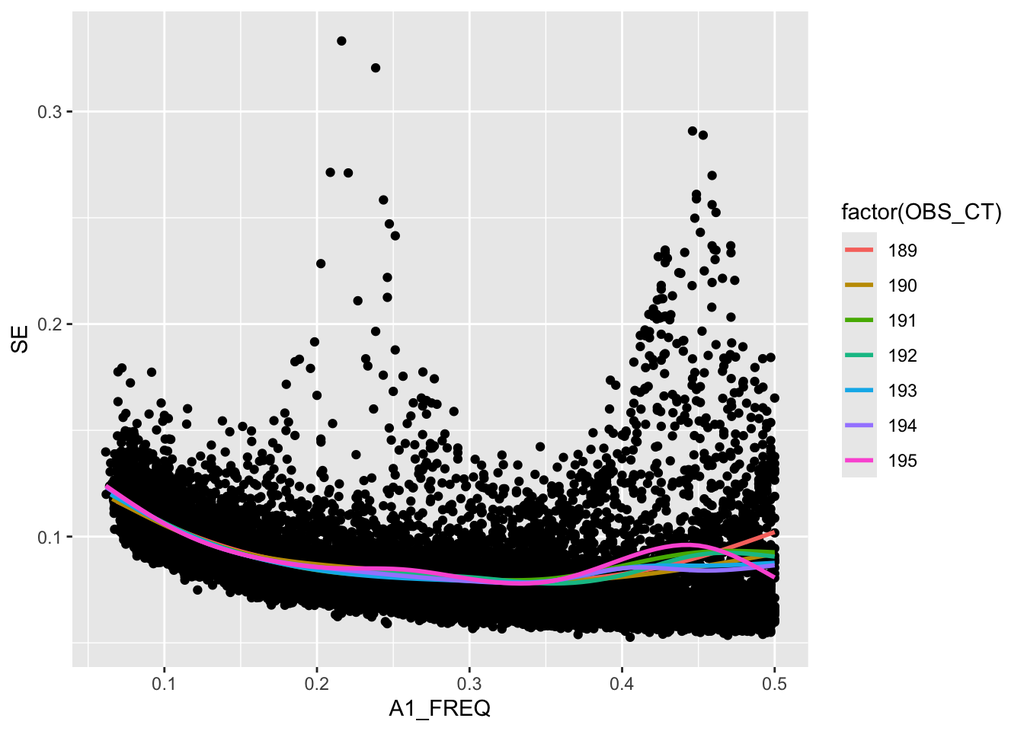

```r
# OBS_CT no es categórica, pero la tratamos como tal con "factor()".
# Observa que el color aquí se mapea sólo en la capa "geom_smooth()",
# para que los puntos sean todos negros.
ggplot(data = gwas,
       mapping = aes(x = A1_FREQ, y = SE)) +
   geom_point() +
   geom_smooth(mapping = aes(color = factor(OBS_CT)), se = FALSE)
```

Otra forma de agrupar los datos es mediante las *facetas*:

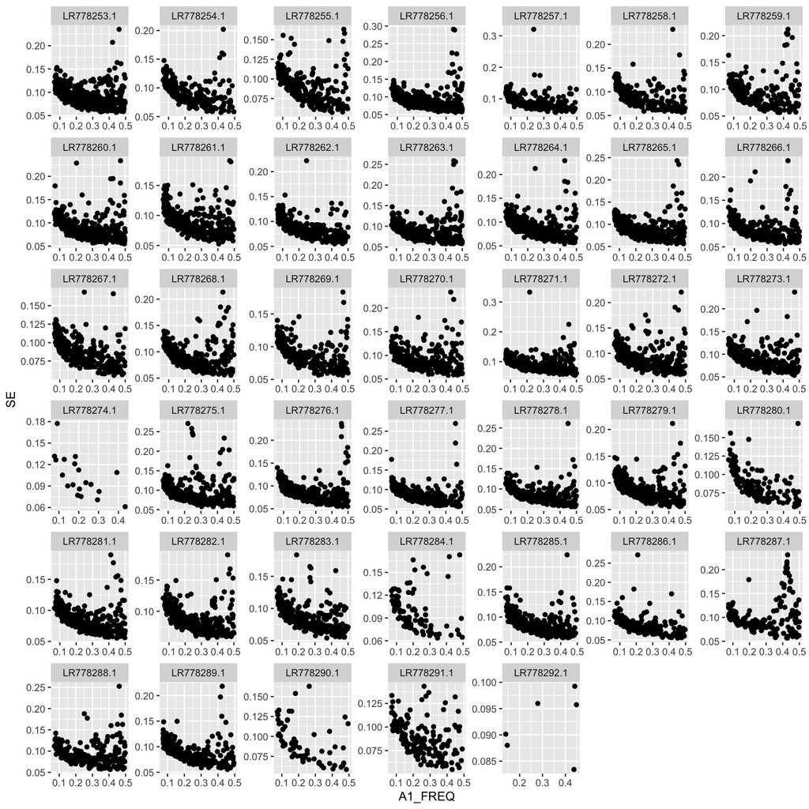

```r
ggplot(data = gwas,
       mapping = aes(x = A1_FREQ, y = SE)) +
   geom_point() +
   facet_wrap(~CHROM, scale = 'free')
```

**NotaDesafíos**

1. Haz que no sólo las líneas, sino también los puntos tengan colores diferentes, que correspondan a los valores de OBS_CT, en la gráfica donde has usado `geom_smooth()`.

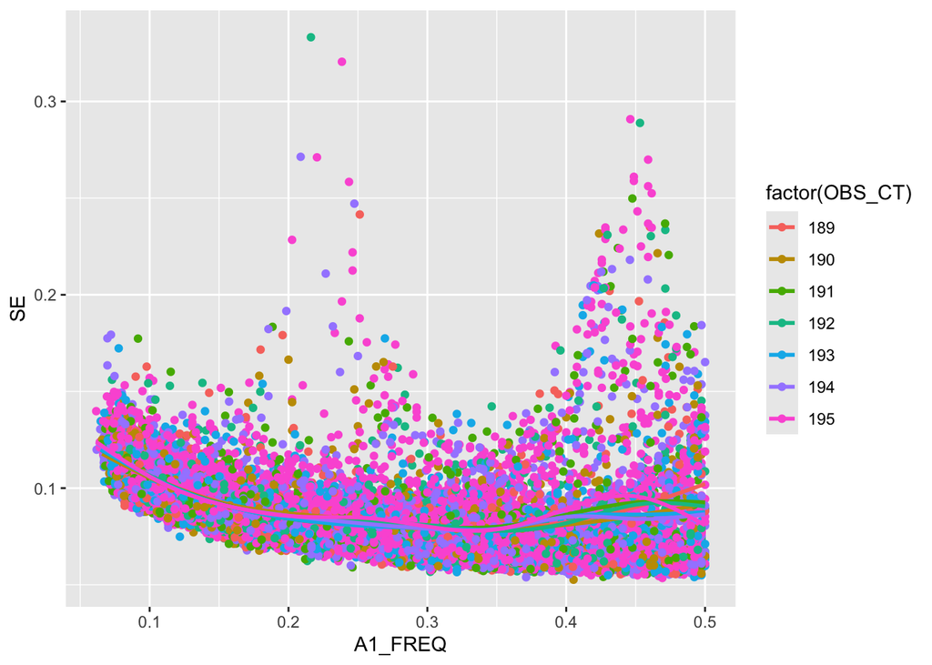

   ```r
   ggplot(data = gwas,
          mapping = aes(x = A1_FREQ, y = SE)) +
      geom_point(mapping = aes(color = factor(OBS_CT))) +
      geom_smooth(mapping = aes(color = factor(OBS_CT)), se = FALSE)
   ```

2. Añade una línea suavizada (`geom_smooth()`) a cada cromosoma en el gráfico anterior.

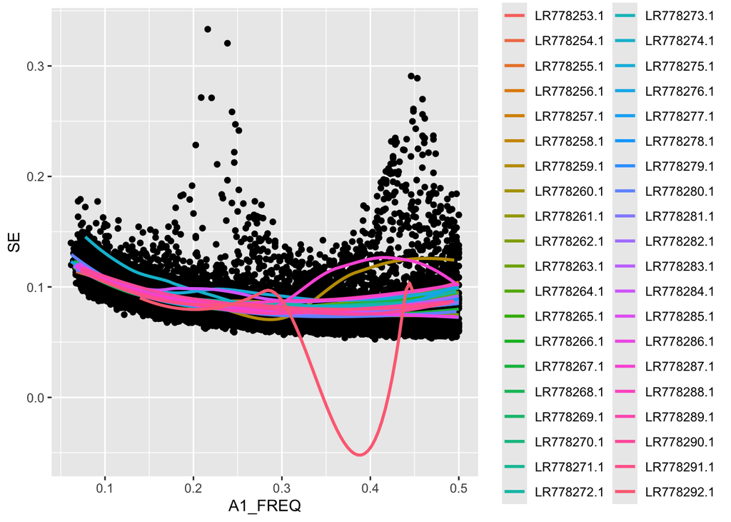

   ```r
   ggplot(data = gwas,
          mapping = aes(x = A1_FREQ, y = SE)) +
      geom_point() +
      geom_smooth(mapping = aes(color = factor(CHROM)), se = FALSE)
   ```

3. ¿Cómo puedes deshacerte de los mensajes de `geom_smooth()`?

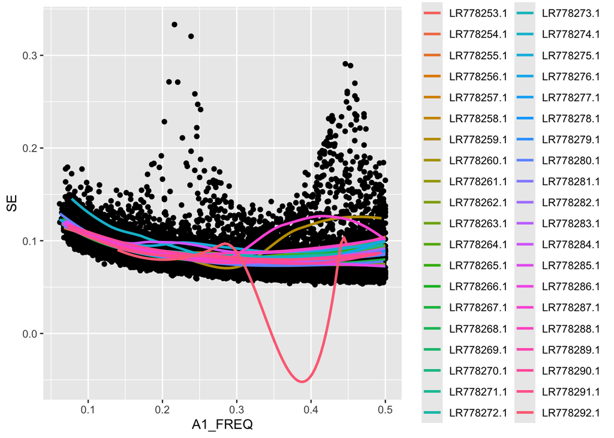

   ```r
   ggplot(data = gwas,
          mapping = aes(x = A1_FREQ, y = SE)) +
      geom_point() +
      geom_smooth(mapping = aes(color = factor(CHROM)), method = 'loess', formula = 'y ~ x', se = FALSE)
   ```

4. ¿Para qué sirve la opción `scale = 'free'` en `facet_wrap()`?

   Hace que cada gráfica tenga su propio eje x e y ajustados según sus datos.

# Agrupación de datos y estadísticos

Al examinar la relación entre el error estándar y el tamaño muestral, podemos tratar el tamaño muestral como variable categórica, porque tiene sólo 7 valores diferentes. Observa cómo en el bloque siguiente añadimos información sobre la media de cada categoría sin modificar el marco de datos, aprovechando la función `stat_summary()`:

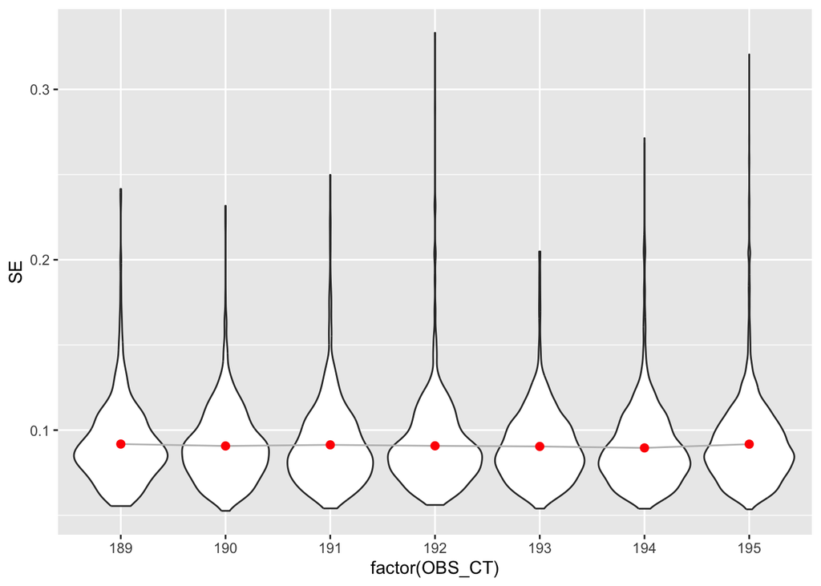

```r
ggplot(data = gwas,
       mapping = aes(x = factor(OBS_CT),
                     y = SE)) +
   geom_violin() +
   # Con "group = 1" definimos un único grupo (cualquier valor constante sirve),
   # para que 1 línea una todos los puntos, en lugar de generar una línea en
   # cada valor de X:
   stat_summary(geom = 'line',
                fun = 'mean',
                group = 1,
                colour = 'gray') +
   # Los puntos, en cambio, son uno para cada grupo:
   stat_summary(geom = 'point',
                fun = 'mean',
                colour = 'red',
                size = 2)
```

Otra forma de representarlo:

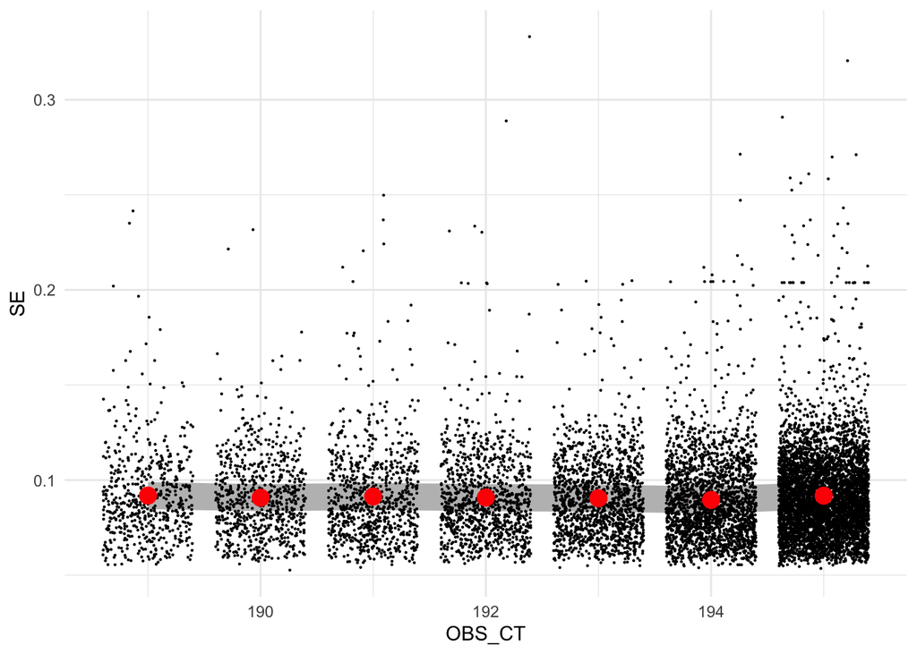

```r
ggplot(data = gwas, aes(x = OBS_CT, y = SE)) +
   stat_summary(geom = 'line', fun = 'mean', linewidth = 7, color = 'gray') +
   geom_point(position = 'jitter', size = 0.1) +
   stat_summary(geom = 'point', fun = 'mean', color = 'red', size = 4) +
   theme_minimal()
```

**NotaDesafío**

1. ¿Para qué sirve la opción `position = 'jitter'`?

   Evita el agrupamiento de los puntos para representar la densidad real.
2. ¿Por qué en la gráfica de violines teníamos que especificar `group = 1` y en la siguiente no, al representar la línea?

   Para que represente solo una línea que una los puntos y no intente poner una línea por punto.
3. ¿Para qué sirve la función `factor()` al representar la gráfica de violines?

   Para separar los datos en varios grupos según el tamaño muestral y no combinarlos todos en un mismo violín.
4. ¿Se te ocurre alguna otra manera de combinar datos y sus estadísticos (como la media) en un mismo gráfico, sin usar `stat_summary()`? ¿Qué método te gusta más?

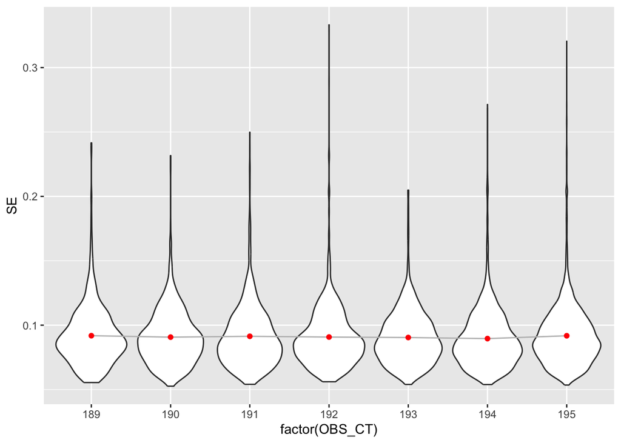

   ```r
   ggplot(data = gwas, mapping = aes(x = factor(OBS_CT), y = SE)) + geom_violin() + geom_line(stat = 'summary', fun = 'mean', group = 1, colour= 'gray') + geom_point(stat = 'summary', fun = 'mean', colour = 'red')
   ```

# Barras

Si combinamos el alelo A1 con el OMITTED, clasificamos cada SNP en una de las 12 posibles combinaciones de dos nucleótidos diferentes. Podemos representar las frecuencias de los 12 tipos de SNPs con un gráfico de barras. Obsérvalo e intenta explicar el patrón.

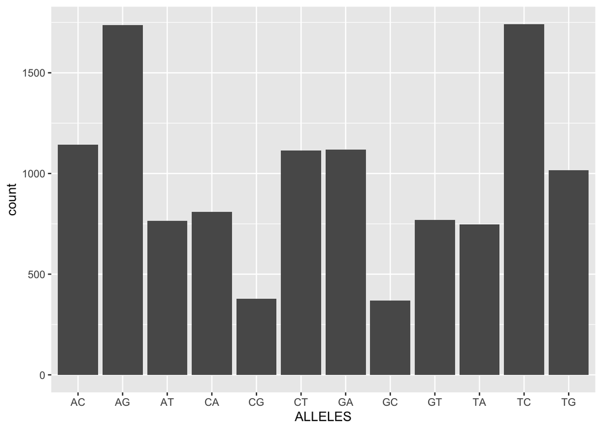

```r
gwas$ALLELES <- paste0(gwas$A1, gwas$OMITTED)
ggplot(data = gwas, mapping = aes(x = ALLELES)) + geom_bar(stat = 'count')
```

`geom_bar()` automáticamente representa el número de observaciones de cada tipo. Este geométrico usa el estético `fill` para el color de las barras. Podemos mapear una variable categórica a `fill`. Por ejemplo, ahora que tenemos clasificados los SNPs en 12 categorías, veamos cuántos hay de cada tipo en cada cromosoma:

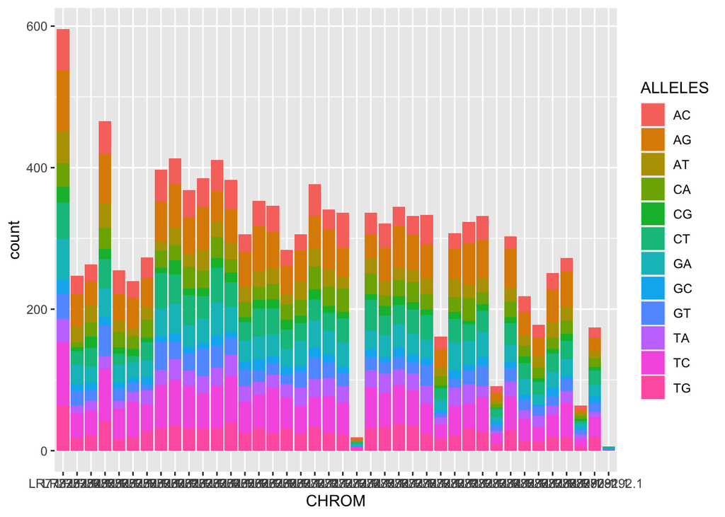

```r
ggplot(data = gwas, mapping = aes(x= CHROM, fill = ALLELES)) +
   geom_bar()
```

**NotaDesafíos**

1. Genera una nueva variable categórica en `gwas` que indique si el SNP es una transición (AG, GA, CT, TC) o una transversión (los otros) y comprueba con un diagrama de barras si las proporciones son comparables entre cromosomas.

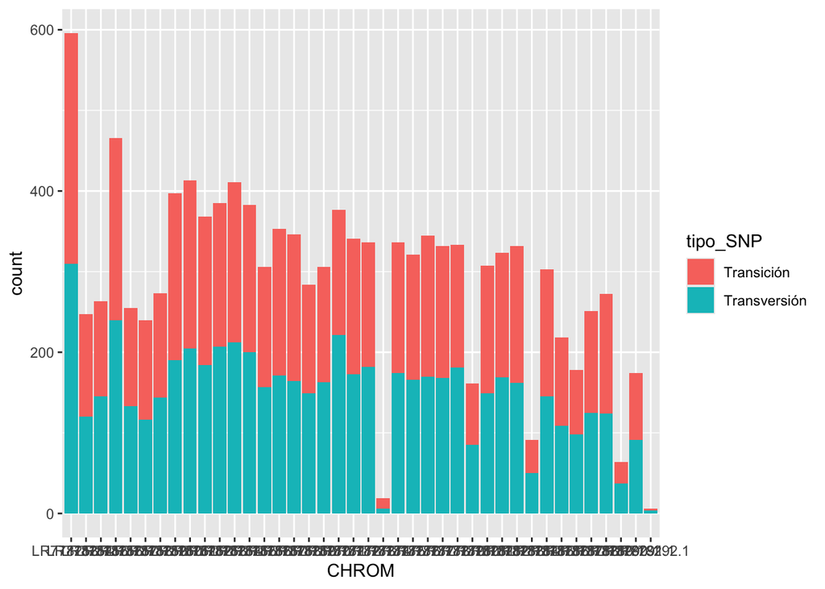

   ```r
   gwas$tipo_SNP <- ifelse(gwas$ALLELES %in% c('AG', 'GA', 'CT', 'TC'), 'Transición', 'Transversión')
   ggplot(data = gwas, mapping = aes(x= CHROM, fill = tipo_SNP)) +
      geom_bar()
   ```

2. Mira también si existe relación entre el tipo de mutación y la frecuencia alélica.

   Representamos un histograma para la frecuencia alélica y dividimos cada columna según el número de mutaciones de cada tipo que tiene. Vemos que independientemente de la frecuencia alélica el número de transiciones y transversiones son más o menos iguales.

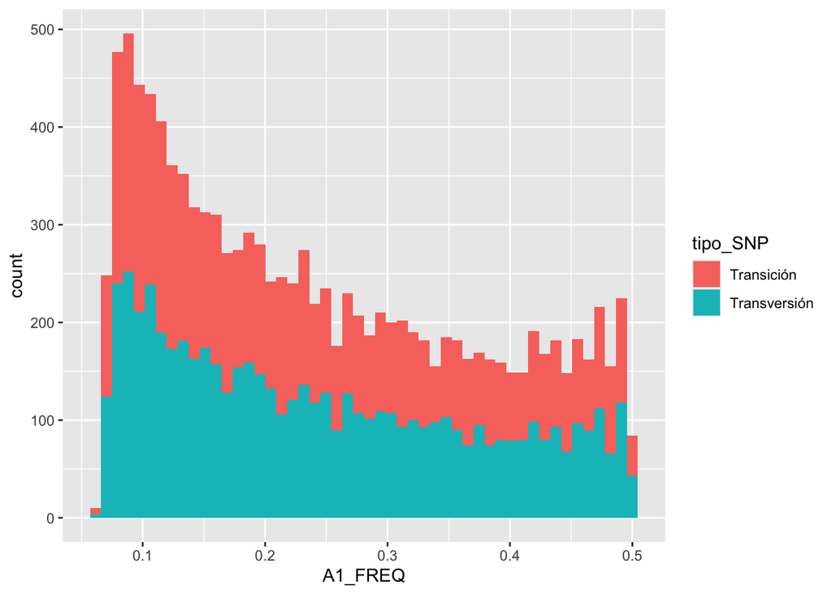

   ```r
   ggplot(data = gwas, mapping = aes(x= A1_FREQ, fill = tipo_SNP)) +
      geom_histogram(bins = 50)
   ```

# Gráficas de volcán

Las gráficas de volcán representan simultáneamente la significación de cada resultado (valor *p*) y la magnitud (y el signo) del efecto estimado. Los valores *p* se muestran en escala logarítmica y con el signo cambiado, para que los resultados más significativos destaquen como *mayores*. Podemos añadir algunas líneas que indiquen los umbrales arbitrarios que utilizamos para seleccionar los resultados creíbles, o bien añadir color a los puntos seleccionados como positivos. A la hora de decidir estos umbrales es fundamental conocer la tasa de falsos positivos esperada con cada umbral (FDR). Para ello, añadimos al marco de datos una columna con el valor *q* [^1], calculado con la función `qvalue()` del paquete `qvalue` (Storey et al. 2025).

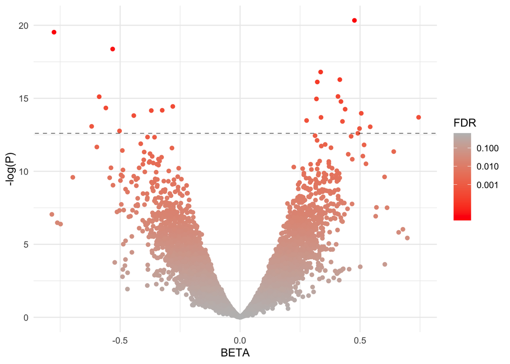

```r
library('qvalue')
gwas$q <- qvalue(gwas$P)$qvalues
# gwas$q <- p.adjust(gwas$P, method = 'fdr'), si no tenemos qvalue
ggplot(data = gwas,
       mapping = aes(x = BETA, y = -log(P), color = q)) +
   geom_point() +
   scale_color_gradient(name = 'FDR', trans = 'log',
                        breaks = c(0.001, 0.01, 0.1),
                        low= 'red', high='gray') +
   geom_abline(intercept = -log(max(gwas[gwas$q <= 0.001, 'P'])),
               slope = 0, linewidth = 0.2, linetype = 2, color = 'black') +
   theme_minimal()
```

**NotaDesafíos**

1. Genera una gráfica de volcán para cada cromosoma.

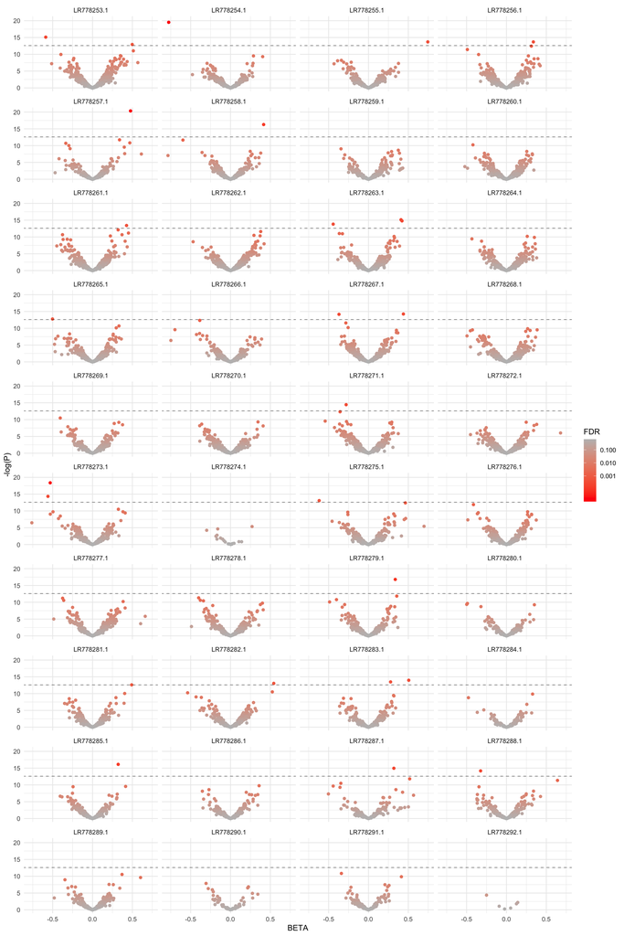

   ```r
   ggplot(data = gwas,
          mapping = aes(x = BETA, y = -log(P), color = q)) +
      geom_point() +
      scale_color_gradient(name = 'FDR', trans = 'log',
                           breaks = c(0.001, 0.01, 0.1),
                           low= 'red', high='gray') +
      geom_abline(intercept = -log(max(gwas[gwas$q <= 0.001, 'P'])),
                  slope = 0, linewidth = 0.2, linetype = 2, color = 'black') +
      theme_minimal() +
      facet_wrap(~ CHROM, ncol = 4)
   ```

2. El número de SNPs cuyo genotipo está significativamente asociado al fenotipo, ¿te parece elevado o bajo?

   Serán significativos todos aquellos datos que tengan un p-valor menor a 0,005. Teniendo en cuenta la cantidad de genes estudiados me parece bajo.

   ```r
   nrow(gwas)
   ```

   ```
   [1] 11712
   ```

   ```r
   sum(gwas$P < 5e-3)
   ```

   ```
   [1] 814
   ```

3. Escoge un umbral y clasifica los SNPs en “positivos” y “negativos”, y explora la proporción de positivos por cromosoma. ¿Puedes hacerlo sin añadir una columna al marco de datos?

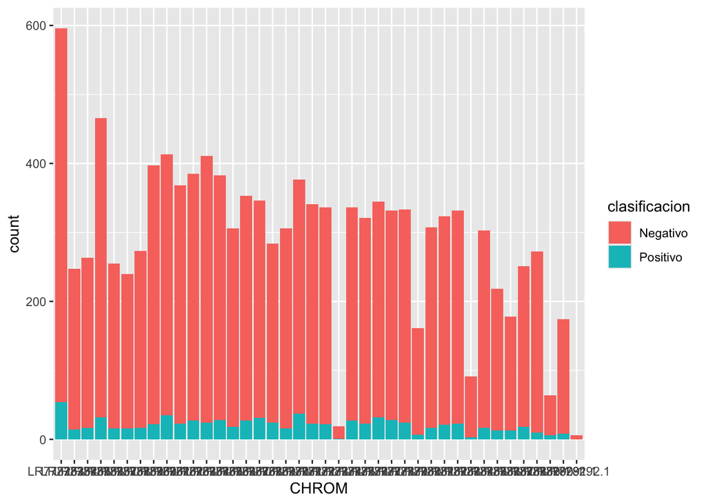

   ```r
   clasificacion <- ifelse(gwas$P < 5e-3, "Positivo", "Negativo")
   ggplot(data = gwas, mapping = aes(x= CHROM, fill = clasificacion)) +
      geom_bar()
   ```

# Gráfica de Manhattan

Las gráficas más características de los estudios de asociación genómica son las de Manhattan, donde la posición de los puntos a lo largo del eje horizontal se corresponde con la posición en el cromosoma, y la altura del punto es proporcional a su significación. Lo difícil es poner los cromosomas unos detrás de otros y alternar el color de los puntos en cada cromosoma. Para ello, no tenemos más remedio que añadir algunas columnas al marco de datos (o bien usar algún paquete de R específico, pero no hace falta).

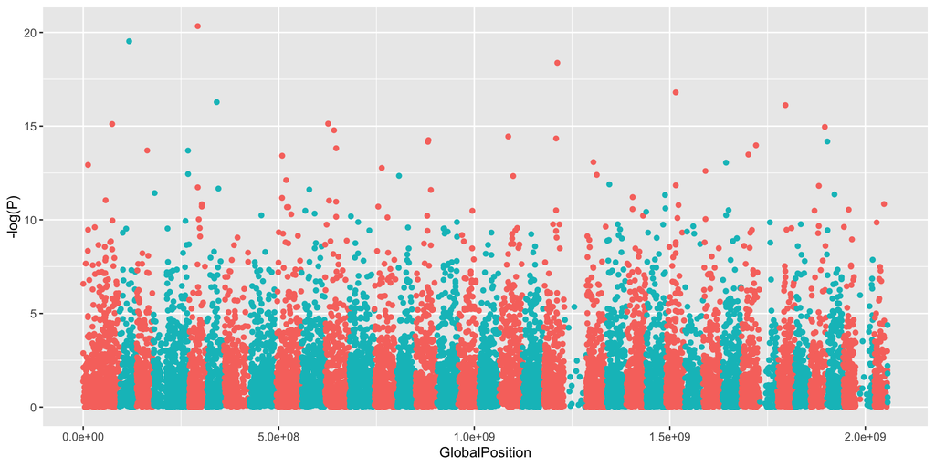

```r
# Como no tenemos a mano la longitud de cada cromosoma, usaremos su posición máxima.
PosicionMaxima <- sapply(split(gwas$POS, gwas$CHROM), max)

# Al colocar los cromosomas uno detrás de otro, la coordenada global de un SNP
# es la suma de su posición en el cromosoma y las longitudes de todos los cromosomas
# anteriores. Este último término lo llamo "offset" y es 0 para el primer cromosoma,
# la longitud del primero para el segundo, etc hasta la suma de las longitudes de
# todos los cromosomas menos el último, para el último.
n <- length(PosicionMaxima)
offset <- c(0, cumsum(PosicionMaxima[-n]))
# Hay que corregir los nombre del vector "offset":
names(offset) <- names(PosicionMaxima)
# Añadimos el "offset" a cada SNP de gwas:
gwas$offset <- offset[gwas$CHROM]
gwas$GlobalPosition <- gwas$offset + gwas$POS
# Faltan los colores alternantes entre cromosomas. Una estrategia puede ser esta:
colorCromosoma <- rep(c('A', 'B'), n / 2)
names(colorCromosoma) <- names(PosicionMaxima)
gwas$color <- colorCromosoma[gwas$CHROM]

ggplot(data = gwas, mapping = aes(x = GlobalPosition, y = -log(P), color = color)) +
   geom_point() + theme(legend.position = 'none')
```

# Información de la sesión

## Bibliografía

Chang, C. C., C. C. Chow, L. C. A. M. Tellier, S. Vattikuti, S. M. Purcell, y J. J. Lee. 2015. «Second-generation PLINK: rising to the challenge of larger and richer datasets». *GigaScience* 4 (1): s13742-015-0047-8. https://doi.org/10.1186/s13742-015-0047-8.

Purcell, S., B. Neale, K. Todd-Brown, L. Thomas, M. A. R. Ferreira, D. Bender, J. Maller, et al. 2007. «PLINK: A Tool Set for Whole-Genome Association and Population-Based Linkage Analyses». *American Journal of Human Genetics* 81 (3): 559-75. https://doi.org/10.1086/519795.

Storey, John D., Andrew J. Bass, Alan Dabney, y David Robinson. 2025. *qvalue: Q-value estimation for false discovery rate control*. https://doi.org/10.18129/B9.bioc.qvalue.

## Notas

[^1]: El valor *q* de un test es la proporción de falsos positivos que esperamos entre todos los resultados con un valor *p* menor o igual al de ese test.